# **SpaceX Falcon 9 first stage Landing Prediction**

## Guide to Launch Orbits, via Wikipedia

- **LEO**: Low Earth orbit (LEO)is an Earth-centred orbit with an altitude of 2,000 km (1,200 mi) or less (approximately one-third of the radius of Earth),[1] or with at least 11.25 periods per day (an orbital period of 128 minutes or less) and an eccentricity less than 0.25.[2] Most of the manmade objects in outer space are in LEO [1].
- **VLEO**: Very Low Earth Orbits (VLEO) can be defined as the orbits with a mean altitude below 450 km. Operating in these orbits can provide a number of benefits to Earth observation spacecraft as the spacecraft operates closer to the observation[2].
- **GTO** A geosynchronous orbit is a high Earth orbit that allows satellites to match Earth's rotation. Located at 22,236 miles (35,786 kilometers) above Earth's equator, this position is a valuable spot for monitoring weather, communications and surveillance. Because the satellite orbits at the same speed that the Earth is turning, the satellite seems to stay in place over a single longitude, though it may drift north to south,” NASA wrote on its Earth Observatory website [3] .
- **SSO (or SO)**: It is a Sun-synchronous orbit also called a heliosynchronous orbit is a nearly polar orbit around a planet, in which the satellite passes over any given point of the planet's surface at the same local mean solar time [4] .
- **ES-L1** :At the Lagrange points the gravitational forces of the two large bodies cancel out in such a way that a small object placed in orbit there is in equilibrium relative to the center of mass of the large bodies. L1 is one such point between the sun and the earth [5].
- **HEO** A highly elliptical orbit, is an elliptic orbit with high eccentricity, usually referring to one around Earth [6].
- **ISS** A modular space station (habitable artificial satellite) in low Earth orbit. It is a multinational collaborative project between five participating space agencies: NASA (United States), Roscosmos (Russia), JAXA (Japan), ESA (Europe), and CSA (Canada) [7]
- **MEO** Geocentric orbits ranging in altitude from 2,000 km (1,200 mi) to just below geosynchronous orbit at 35,786 kilometers (22,236 mi). Also known as an intermediate circular orbit. These are "most commonly at 20,200 kilometers (12,600 mi), or 20,650 kilometers (12,830 mi), with an orbital period of 12 hours [8]
- **HEO** Geocentric orbits above the altitude of geosynchronous orbit (35,786 km or 22,236 mi) [9]
- **GEO** It is a circular geosynchronous orbit 35,786 kilometres (22,236 miles) above Earth's equator and following the direction of Earth's rotation [10]
- **PO** It is one type of satellites in which a satellite passes above or nearly above both poles of the body being orbited (usually a planet such as the Earth [11]

```python
geocentric_orbit_order = [
    'VLEO',
    'LEO',
    'ISS',
    'SSO',
    'PO',
    'MEO',
    'HEO',
    'GTO',
    'GEO',
    'SO',
    'ES-L1'
]
```

### Relationship between success rate of each orbit type

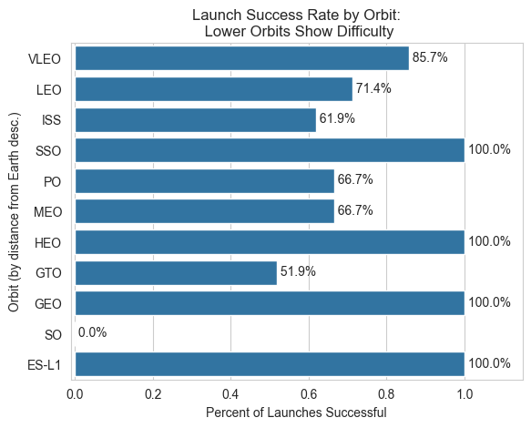

```python
def add_val_annot(df:pd.DataFrame,col):
    for ind,tick in enumerate(geocentric_orbit_order):
        # get score from df
        score = df.loc[df["Orbit"] == tick, col].values[0]
        plt.annotate(f" {score:.1%}",((float(score),ind+.1)))
orbz = df.groupby("Orbit",as_index=False)["Class"].mean()
sns.barplot(data=orbz,y="Orbit",x="Class",orient="h",order=geocentric_orbit_order)
add_val_annot(orbz,"Class")
plt.title("Launch Success Rate by Orbit:\n Lower Orbits Show Difficulty")
plt.ylabel("Orbit (by distance from Earth desc.)")
plt.xlabel("Percent of Launches Successful")
plt.xlim(-0.01,1.15)
plt.show()
```

### Relationship between FlightNumber and Orbit type

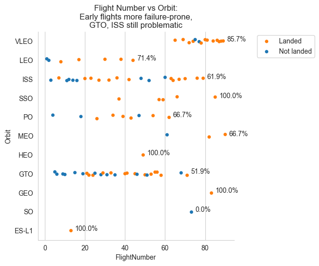

```python
# Plot a scatter point chart with x axis to be FlightNumber and y axis to be the Orbit, and hue to be the class value
# TODO: title, legend, order of Orbits
sns.catplot(x="FlightNumber",y="Orbit", hue="Class",data=df,order=geocentric_orbit_order,legend=False)
for ind, tick in enumerate(geocentric_orbit_order):
    frame = df[df["Orbit"]==tick]
    score=frame["Class"].mean()
    plt.annotate(f"{score:.1%}",(frame["FlightNumber"].max()+2,ind))
leg = plt.legend(["Landed","Not landed"])
leg.set_bbox_to_anchor((1.1,1))
plt.title("Flight Number vs Orbit:\nEarly flights more failure-prone,\nGTO, ISS still problematic")
plt.savefig("orbit_v_outcome.png", bbox_inches="tight")
plt.show()
```

You should see that in the LEO orbit the Success appears related to the number of flights; on the other hand, there seems to be no relationship between flight number when in GTO orbit.

### Relationship between Payload and Orbit type

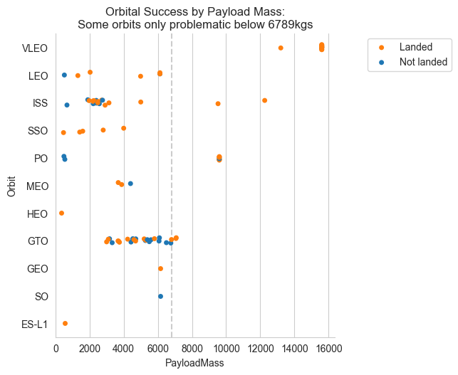

```python
# Plot a scatter point chart with x axis to be Payload and y axis to be the Orbit, and hue to be the class value
sns.catplot(x="PayloadMass",y="Orbit",hue="Class",data=df,order=geocentric_orbit_order,legend=False)
leg = plt.legend(["Landed","Not landed"])
leg.set_bbox_to_anchor((1.1,1))
mean_success= df[df["Class"]>0]["PayloadMass"].mean()
plt.title(f"Orbital Success by Payload Mass:\nSome orbits only problematic below {mean_success:.0f}kgs")
top,bot =plt.ylim()
plt.vlines(mean_success,top,bot,colors="grey",linestyles="dashed",alpha=0.4)
plt.ylim(top,bot)
plt.xlim(left=0)
plt.savefig("orbit_v_mass.png", bbox_inches="tight")
plt.show()
```

With heavy payloads the successful landing or positive landing rate are more for Polar,LEO and ISS.

However for GTO we cannot distinguish this well as both positive landing rate and negative landing(unsuccessful mission) are both there here.

## Represent Yearly Successes Overall

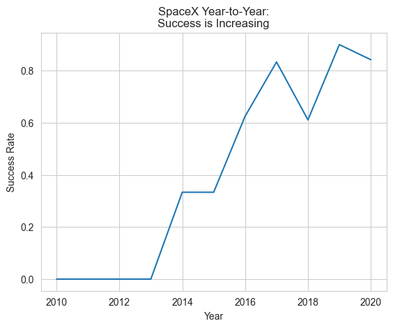

```python
yr_succ = df.groupby("Year",as_index=False)["Class"].mean()
sns.lineplot(yr_succ,x="Year",y="Class")
plt.xlabel("Year")
plt.ylabel("Success Rate")
plt.title("SpaceX Year-to-Year:\nSuccess is Increasing")
plt.show()
```

## Features Engineering

```python
features = df[['FlightNumber', 'PayloadMass', 'PayloadMass_Missingness','Orbit', 'LaunchSite', 'Flights', 'GridFins', 'Reused', 'Legs', 'LandingPad', 'Block', 'ReusedCount']]
features.head()
```

|  | FlightNumber | PayloadMass | PayloadMass_Missingness | Orbit | LaunchSite | Flights | GridFins | Reused | Legs | LandingPad | Block | ReusedCount |
| --- | --- | --- | --- | --- | --- | --- | --- | --- | --- | --- | --- | --- |
| 4 | 1 | 6123.547647 | 1 | LEO | CCSFS SLC 40 | 1 | False | False | False | None | 1.0 | 0 |
| 5 | 2 | 525.000000 | 0 | LEO | CCSFS SLC 40 | 1 | False | False | False | None | 1.0 | 0 |
| 6 | 3 | 677.000000 | 0 | ISS | CCSFS SLC 40 | 1 | False | False | False | None | 1.0 | 0 |
| 7 | 4 | 500.000000 | 0 | PO | VAFB SLC 4E | 1 | False | False | False | None | 1.0 | 0 |
| 8 | 5 | 3170.000000 | 0 | GTO | CCSFS SLC 40 | 1 | False | False | False | None | 1.0 | 0 |

Convert launch site to one-hot encoding

```python
sub_feat = ["Orbit", "LaunchSite", "LandingPad"]
features_one_hot = pd.get_dummies(features[sub_feat])
features = features.drop(sub_feat, axis = 1)
features_one_hot = features_one_hot.join(features)
features_one_hot.astype("Float64")
features_one_hot.head()
```

|  | Orbit_ES-L1 | Orbit_GEO | Orbit_GTO | Orbit_HEO | Orbit_ISS | Orbit_LEO | Orbit_MEO | Orbit_PO | Orbit_SO | Orbit_SSO | Orbit_VLEO | LaunchSite_CCSFS SLC 40 | LaunchSite_KSC LC 39A | LaunchSite_VAFB SLC 4E | LandingPad_5e9e3032383ecb267a34e7c7 | LandingPad_5e9e3032383ecb554034e7c9 | LandingPad_5e9e3032383ecb6bb234e7ca | LandingPad_5e9e3032383ecb761634e7cb | LandingPad_5e9e3033383ecbb9e534e7cc | FlightNumber | PayloadMass | PayloadMass_Missingness | Flights | GridFins | Reused | Legs | Block | ReusedCount |
| --- | --- | --- | --- | --- | --- | --- | --- | --- | --- | --- | --- | --- | --- | --- | --- | --- | --- | --- | --- | --- | --- | --- | --- | --- | --- | --- | --- | --- |
| 4 | False | False | False | False | False | True | False | False | False | False | False | True | False | False | False | False | False | False | False | 1 | 6123.547647 | 1 | 1 | False | False | False | 1.0 | 0 |
| 5 | False | False | False | False | False | True | False | False | False | False | False | True | False | False | False | False | False | False | False | 2 | 525.000000 | 0 | 1 | False | False | False | 1.0 | 0 |
| 6 | False | False | False | False | True | False | False | False | False | False | False | True | False | False | False | False | False | False | False | 3 | 677.000000 | 0 | 1 | False | False | False | 1.0 | 0 |
| 7 | False | False | False | False | False | False | False | True | False | False | False | False | False | True | False | False | False | False | False | 4 | 500.000000 | 0 | 1 | False | False | False | 1.0 | 0 |
| 8 | False | False | True | False | False | False | False | False | False | False | False | True | False | False | False | False | False | False | False | 5 | 3170.000000 | 0 | 1 | False | False | False | 1.0 | 0 |

Export to CSV

```python
features_one_hot.to_csv('dataset_part_3.csv', index=False)
```

## Correlation Analysis:

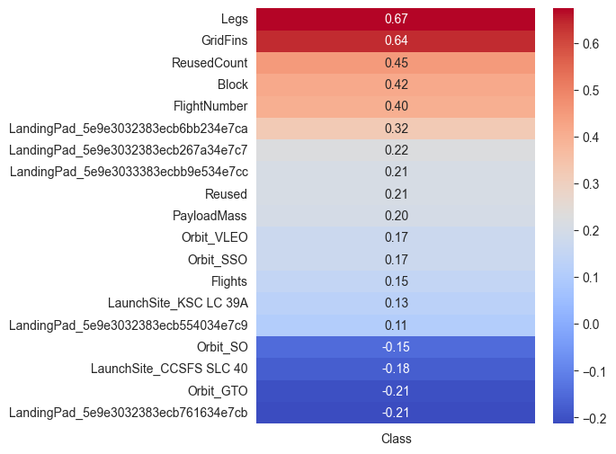

```python
plt.figure(figsize=(5,6))

corr_mat = features_one_hot.copy()
corr_mat["Class"]= df["Class"]
ws_corr = corr_mat.corr(numeric_only=True)["Class"]
corr_thresh= 0.1
droplist = []
for ind,x in ws_corr.items():
    if not (x > corr_thresh or x < -corr_thresh):
        droplist.append(ind)
ws_corr.drop(droplist+["Class"],axis=0,inplace=True)
ws_corr.sort_values(inplace=True,ascending=False)
sns.heatmap(pd.DataFrame(ws_corr),annot=True,fmt=".2f",cmap=sns.color_palette("coolwarm",as_cmap=True))
plt.savefig("corr_api.png", bbox_inches="tight")
plt.show()
```

# Construct Model

## Train,Test Split

```python
#train test split
X = features_one_hot.copy()
Y = df["Class"].to_numpy()
X_train, X_test, Y_train, Y_test = train_test_split(X,Y,test_size=0.2,random_state=2,stratify=Y)
```

##### CV Params

```python
refit="f1"
scoring = ["f1","recall","accuracy"]
```

## Init Models

```python
# SVC
#param_grid = {'kernel':('linear', 'rbf','poly','rbf', 'sigmoid'),
#    'C': np.logspace(-3, 3, 5),
#    'gamma':np.logspace(-3, 3, 5)}
#svm = SVC()
#svm_cv = GridSearchCV(svm,cv=10,param_grid=param_grid,refit=refit,scoring=scoring)
```

```python
# Decision Tree
param_grid = {'criterion': ['gini', 'entropy'],
    'splitter': ['best', 'random'],
    'max_depth': [2*n for n in range(1,10)],
    'max_features': ['sqrt'], #no more "auto"
    'min_samples_leaf': [1, 2, 4],
    'min_samples_split': [2, 5, 10],
    'random_state':[42]}
tree = DecisionTreeClassifier()
tree_cv = GridSearchCV(tree,cv=10,param_grid=param_grid,refit=refit,scoring=scoring)
```

```python
# Random forest
rf = RandomForestClassifier()
param_grid = {
    'n_estimators': [100, 200],
    'max_depth': [3, 5, 7],
    'min_samples_split': [2, 5, 10],
    'min_samples_leaf': [1, 2, 4],
    'max_features': ['sqrt', None],
    'bootstrap': [True],
    'class_weight': ['balanced', 'balanced_subsample', None],
    'n_jobs':[-1]
}
rf_cv = GridSearchCV(rf,cv=10,param_grid=param_grid,refit=refit,scoring=scoring)
```

```python
# XGBoost Clf
xgb = XGBClassifier(objective="binary:logistic")
param_grid = {
    'n_estimators': [100, 200, 300],
    'max_depth': [3, 4, 5, 6],
    'learning_rate': [0.01],
    'subsample': [0.8, 1.0],
    'colsample_bytree': [0.8, 1.0],
    'min_child_weight': [1, 3, 5],
    'gamma': [0.1],
    'n_jobs':[-1]
}
xgb_cv = GridSearchCV(xgb,cv=10,param_grid=param_grid,refit=refit,scoring=scoring)
```

## Train Models

Train/Save Helper

```python
def train_model(model,model_name,X_train,Y_train):
    model_path = f"{model_name}.pkl"
    if os.path.exists(model_path):
        with open(model_path,"rb") as file:
            model= pickle.load(file)
        return model
    else:
        model.fit(X_train,Y_train)
        with open(model_path,"wb") as file:
            pickle.dump(model,file)
        return model
```

```python
# train decision tree
tree_cv = train_model(tree_cv,"DecisionTree",X_train,Y_train)
```

```python
# train random forest
rf_cv = train_model(rf_cv,"RandomForestClassifier",X_train,Y_train)
```

```python
# train xgb
xgb_cv = train_model(xgb_cv,"XGBClassifier",X_train,Y_train)
```

# Evaluate Model Performance

```python
scores = pd.DataFrame({"model":[],f"{refit} score":[]})
```

## Eval Helper Function

```python
def eval_model(model:GridSearchCV,model_name,X_test,Y_test,score_df=scores):
    print("best hyperparameters:",model.best_params_)
    score= model.score(X_test,Y_test)
    results = {"model":[model_name],f"{refit} score":[score]}
    print(f"best {refit} score: {score:.1%}")
    score_df = pd.concat([score_df,pd.DataFrame(results)],ignore_index=True)
    y_hat = model.predict(X_test)
    plot_confusion_matrix(Y_test,y_hat,model_name)
    return score_df
```

Decision Tree Evaluation

```
best hyperparameters: {'criterion': 'gini', 'max_depth': 4, 'max_features': 'sqrt', 'min_samples_leaf': 1, 'min_samples_split': 10, 'random_state': 42, 'splitter': 'best'}
best f1 score: 72.7%
```

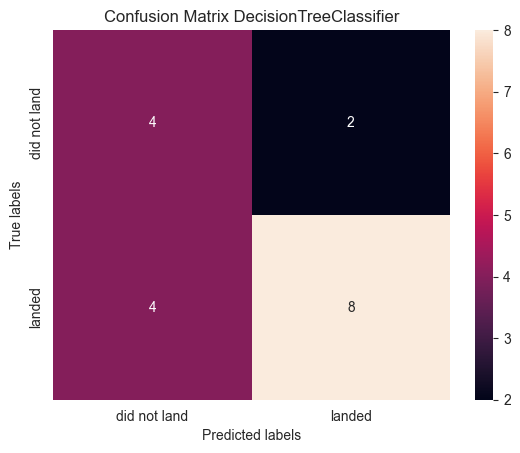

```python
scores= eval_model(tree_cv,"DecisionTreeClassifier",X_test,Y_test,scores)
```

```
best hyperparameters: {'colsample_bytree': 0.8, 'gamma': 0.1, 'learning_rate': 0.01, 'max_depth': 3, 'min_child_weight': 3, 'n_estimators': 300, 'n_jobs': -1, 'subsample': 0.8}
best f1 score: 78.3%
```

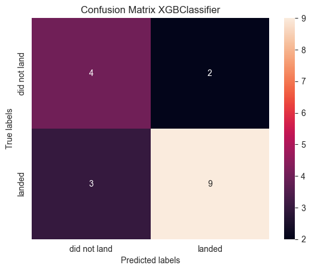

```
best hyperparameters: {'bootstrap': True, 'class_weight': None, 'max_depth': 3, 'max_features': 'sqrt', 'min_samples_leaf': 1, 'min_samples_split': 5, 'n_estimators': 200, 'n_jobs': -1}
best f1 score: 83.3%
```

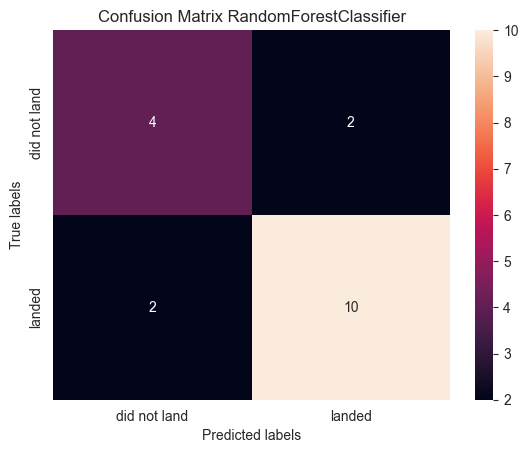

```python
scores= eval_model(xgb_cv,"XGBClassifier",X_test,Y_test,scores)
scores= eval_model(rf_cv,"RandomForestClassifier",X_test,Y_test,scores)
```

## Display All Model Evaluations

```python
scores
```

|  | model | f1 score |
| --- | --- | --- |
| 0 | DecisionTreeClassifier | 0.727273 |
| 1 | XGBClassifier | 0.782609 |
| 2 | RandomForestClassifier | 0.833333 |

# Regression Results Discussion

## EDA From Model Insights: Random Forest

Check Classification report

```python
print(classification_report(Y_test, rf_cv.predict(X_test),target_names=["did not land","landed"]))
```

```
              precision    recall  f1-score   support

did not land       0.67      0.67      0.67         6
      landed       0.83      0.83      0.83        12

    accuracy                           0.78        18
   macro avg       0.75      0.75      0.75        18
weighted avg       0.78      0.78      0.78        18
```

## Inspect Feature Importances

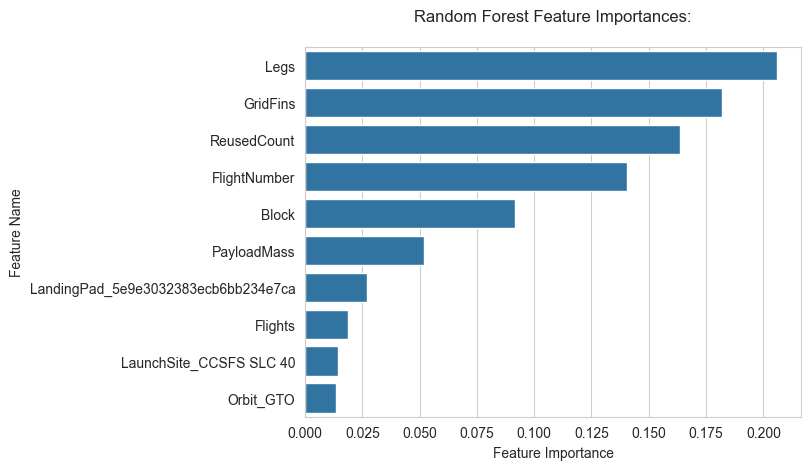

```python
#plt.figure(figsize=(10,6))
max_importances= 10
importances = rf_cv.best_estimator_.feature_importances_
rf_imp_df = pd.DataFrame(importances,index=features_one_hot.columns.to_list()).sort_values(0,ascending=False).head(max_importances)
sns.barplot(rf_imp_df,x=0,y=rf_imp_df.index)
plt.xlabel("Feature Importance")
plt.ylabel("Feature Name")
plt.title("Random Forest Feature Importances:\n")
plt.show()
```

Non Binary : Rocket Reuse

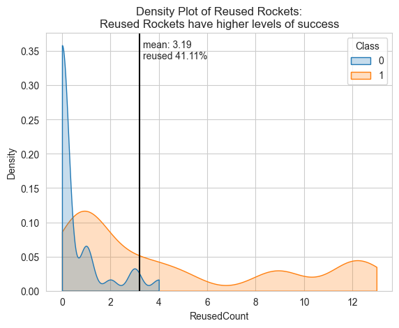

```python
sns.kdeplot(df, x="ReusedCount",cut=0,fill=True,bw_adjust=0.5,hue="Class")
ru_mean=features_one_hot["ReusedCount"].mean()
bot,top = plt.ylim()
plt.vlines(ru_mean,bot,top,color="black")
plt.annotate(f"mean: {ru_mean:0.2f}\nreused {features_one_hot["Reused"].mean():.2%}",(ru_mean*1.05,top*.90))
plt.ylim(bot,top)
plt.title("Density Plot of Reused Rockets:\nReused Rockets have higher levels of success")
plt.show()
```

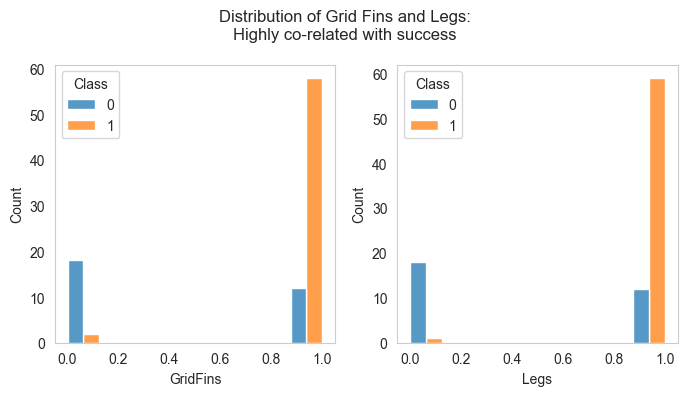

```python
fg, (ax1,ax2)=plt.subplots(1,2,figsize=(7,4))
fg.suptitle("Distribution of Grid Fins and Legs:\nHighly co-related with success")
sns.histplot(df,x="GridFins",hue="Class",multiple="dodge",ax=ax1)
ax1.grid(None)
plt.subplot(1,2,2)
sns.histplot(df,x="Legs",hue="Class",multiple="dodge",ax=ax2)
ax2.grid(None)
plt.tight_layout()
plt.show()
```

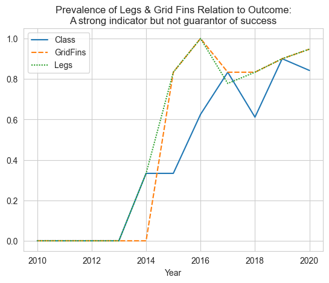

```python
group_legs = df.groupby("Year")[["Class","GridFins","Legs"]].agg("mean")
sns.lineplot(group_legs)
plt.title("Prevalence of Legs & Grid Fins Relation to Outcome:\nA strong indicator but not guarantor of success")
plt.savefig("hardware_v_class_v_time.png", bbox_inches="tight")
plt.show()
```

Adoption of these leg and grid fin designs has coincided with the ongoing success of landings over time.

The SHAP libary is most likely to give us the insight we need to assess importance via impact.

```python
# initialize shap
import shap
shap.initjs()
```

```python
# get explainer
explainer = shap.TreeExplainer(rf_cv.best_estimator_)
shap_values = explainer(X_train)
# verify shape
print(shap_values.shape)
```

```
(72, 28, 2)
```

The results are roughly the same as the Random Forest

### Beeswarm: SHAP

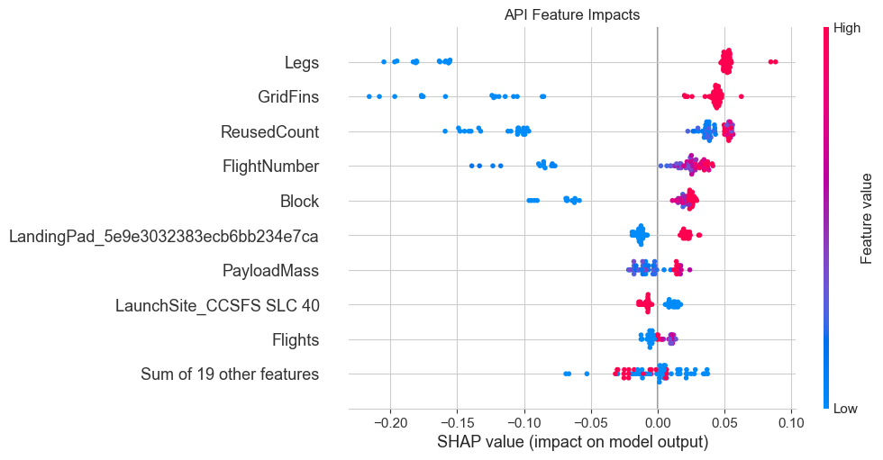

```python
shap.plots.beeswarm(shap_values[:,:,1],show=False)
plt.title("API Feature Impacts")
plt.savefig("beeswarm_landing.png", bbox_inches="tight")
plt.show()
```

Having legs and grid fins were great design improvements. The reuse count served as a good indicator of failure and imperfect indicator of success. Flight numbers are analogous to the passage of time and with it, the likelihood from failure to success. The impact of other features are shown to diminish in either impact or purity.

Let's examine how these were used to make a judgment, using sample at index 2 from the training data.

```
With a value of 1, this would indicate a successful landing.
```

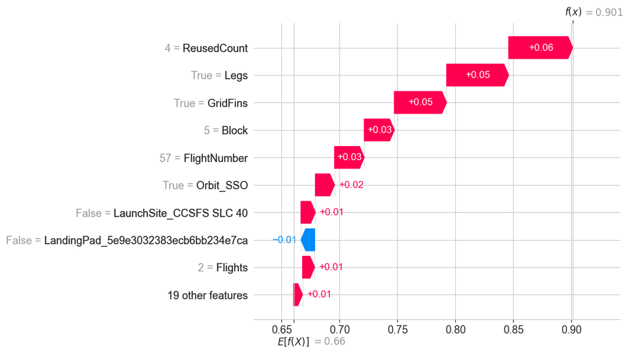

```python
success_dict = {1:'successful',0:'failed'}
print(f"With a value of {Y_train[2]}, this would indicate a {success_dict[int(Y_train[2])]} landing.")
shap.plots.waterfall(shap_values[2,:,1])
```

# Webscrape Dataset Construction

## Features Engineering

```python
df_webscrape.columns
```

```
Index(['Flight No.', 'Launch site', 'Payload', 'Payload mass', 'Orbit',
       'Customer', 'Launch outcome', 'Version Booster', 'Booster landing',
       'Date', 'Time'],
      dtype='object')
```

```python
df_webscrape["Booster landing"].value_counts(True)
```

```
Booster landing
1    0.702479
0    0.297521
Name: proportion, dtype: float64
```

```python
web_features = df_webscrape[['Launch site', 'Payload mass', 'Orbit', 'Customer','Launch outcome', 'Version Booster']]
web_features.head()
```

|  | Launch site | Payload mass | Orbit | Customer | Launch outcome | Version Booster |
| --- | --- | --- | --- | --- | --- | --- |
| 0 | CCSFS | 0 | LEO | SpaceX | 1 | v1.0 |
| 1 | CCSFS | 0 | LEO | NASA | 1 | v1.0 |
| 2 | CCSFS | 525 | LEO | NASA | 1 | v1.0 |
| 3 | CCSFS | 4700 | LEO | NASA | 1 | v1.0 |
| 4 | CCSFS | 4877 | LEO | NASA | 1 | v1.0 |

Convert launch site to one-hot encoding

```python
sub_feat = ['Launch site','Orbit', 'Customer','Version Booster']
ws_feats_oh = pd.get_dummies(web_features[sub_feat])
web_features = web_features.drop(sub_feat, axis = 1)
ws_feats_oh = ws_feats_oh.join(web_features)
ws_feats_oh.astype("Float64")
# export ot CSV
ws_feats_oh.to_csv('dataset_webscrape_part3.csv', index=False)
ws_feats_oh.head()
```

|  | Launch site_CCSFS | Launch site_KSC | Launch site_VAFB | Orbit_GTO | Orbit_HEO | Orbit_LEO | Orbit_MEO | Orbit_SSO | Orbit_Sub-orbital | Customer_ABS | Customer_AsiaSat | Customer_Bulsatcom | Customer_CONAE | Customer_Canadian Space Agency | Customer_EchoStar | Customer_Es'hailSat | Customer_Hisdesat | Customer_Hispasat | Customer_Inmarsat | Customer_Intelsat | Customer_Iridium Communications | Customer_KT Corporation | Customer_MDA | Customer_NASA | Customer_NRO | Customer_NSPO | Customer_Northrop Grumman | Customer_Orbcomm | Customer_PSN | … |
| --- | --- | --- | --- | --- | --- | --- | --- | --- | --- | --- | --- | --- | --- | --- | --- | --- | --- | --- | --- | --- | --- | --- | --- | --- | --- | --- | --- | --- | --- | --- |
| 0 | True | False | False | False | False | True | False | False | False | False | False | False | False | False | False | False | False | False | False | False | False | False | False | False | False | False | False | False | False | … |
| 1 | True | False | False | False | False | True | False | False | False | False | False | False | False | False | False | False | False | False | False | False | False | False | False | True | False | False | False | False | False | … |
| 2 | True | False | False | False | False | True | False | False | False | False | False | False | False | False | False | False | False | False | False | False | False | False | False | True | False | False | False | False | False | … |
| 3 | True | False | False | False | False | True | False | False | False | False | False | False | False | False | False | False | False | False | False | False | False | False | False | True | False | False | False | False | False | … |
| 4 | True | False | False | False | False | True | False | False | False | False | False | False | False | False | False | False | False | False | False | False | False | False | False | True | False | False | False | False | False | … |

## EDA: Correlation Analysis of Webscrape data

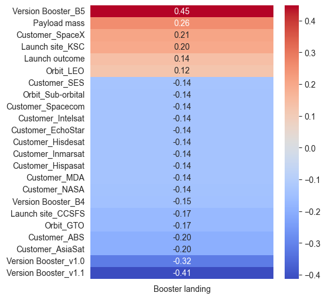

```python
plt.figure(figsize=(5,6))
corr_ws_mat = ws_feats_oh.copy()
corr_ws_mat["Booster landing"] = df_webscrape["Booster landing"]
ws_corr = corr_ws_mat.corr(numeric_only=True)["Booster landing"]
corr_thresh= 0.1
droplist = []
for ind,x in ws_corr.items():
    if not (x > corr_thresh or x < -corr_thresh):
        droplist.append(ind)
ws_corr.drop(droplist+["Booster landing"],axis=0,inplace=True)
ws_corr.sort_values(inplace=True,ascending=False)
sns.heatmap(pd.DataFrame(ws_corr),annot=True,fmt=".2f",cmap=sns.color_palette("coolwarm",as_cmap=True))
plt.savefig("corr_webscrape.png", bbox_inches="tight")
plt.show()
```

## Train, Test Split

```python
x_wb = ws_feats_oh.copy()
y_wb = df_webscrape['Booster landing'].to_numpy()
Xb_train, Xb_test, Yb_train, Yb_test = train_test_split(x_wb,y_wb,test_size=0.2,random_state=2,stratify=y_wb)
print(Xb_train.shape,Xb_test.shape)
```

```
(96, 55) (25, 55)
```

```python
rf_cv = train_model(rf_cv,"RandomForestClassifier_WB",Xb_train,Yb_train)
```

# Webscrape Model Results

```
best hyperparameters: {'bootstrap': True, 'class_weight': None, 'max_depth': 7, 'max_features': 'sqrt', 'min_samples_leaf': 2, 'min_samples_split': 5, 'n_estimators': 100, 'n_jobs': -1}
best f1 score: 92.3%
```

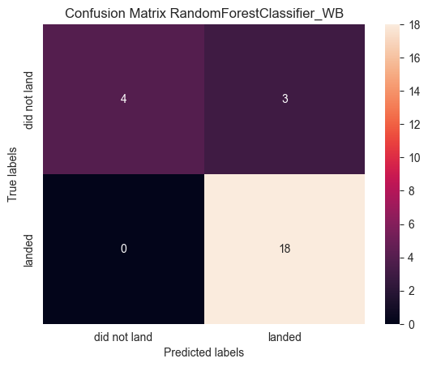

|  | model | f1 score |
| --- | --- | --- |
| 0 | RandomForestClassifier_WB | 0.923077 |

```python
scores_wb = pd.DataFrame({"model":[],f"{refit} score":[]})
eval_model(rf_cv,"RandomForestClassifier_WB",Xb_test,Yb_test,scores_wb)
```

```python
print(classification_report(Yb_test, rf_cv.predict(Xb_test),target_names=["did not land","landed"]))
```

```
              precision    recall  f1-score   support

did not land       1.00      0.57      0.73         7
      landed       0.86      1.00      0.92        18

    accuracy                           0.88        25
   macro avg       0.93      0.79      0.83        25
weighted avg       0.90      0.88      0.87        25
```

## SHAP: Webscrape

```python
# get explainer
explainer_wb = shap.TreeExplainer(rf_cv.best_estimator_)
shap_values_wb = explainer_wb(Xb_train)
# verify shape
print(shap_values_wb.shape)
```

```
(96, 55, 2)
```

### Beeswarm: Webscrape SHAP

```
<function matplotlib.pyplot.show(close=None, block=None)>
```

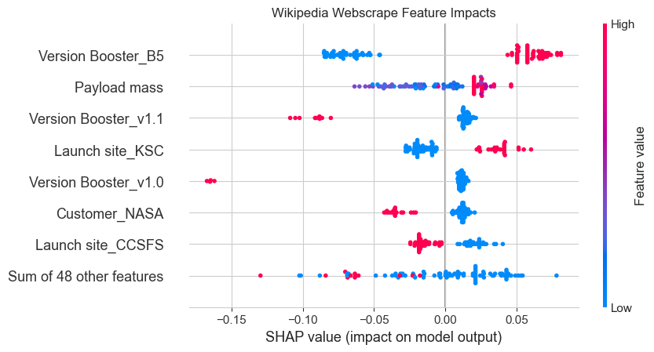

```python
shap.plots.beeswarm(shap_values_wb[:,:,1],max_display=8,show=False)
plt.title("Wikipedia Webscrape Feature Impacts")
plt.savefig("beeswarm_webscrape.png", bbox_inches="tight")
plt.show
```